# Do Discounts Pay Off? Shopify Sales 2023–2025

Total revenue

$59.6M

Orders

60,000

Average order value

$994

Given away in discounts

$13.2M

Monthly revenue (June 2025 is a partial month)

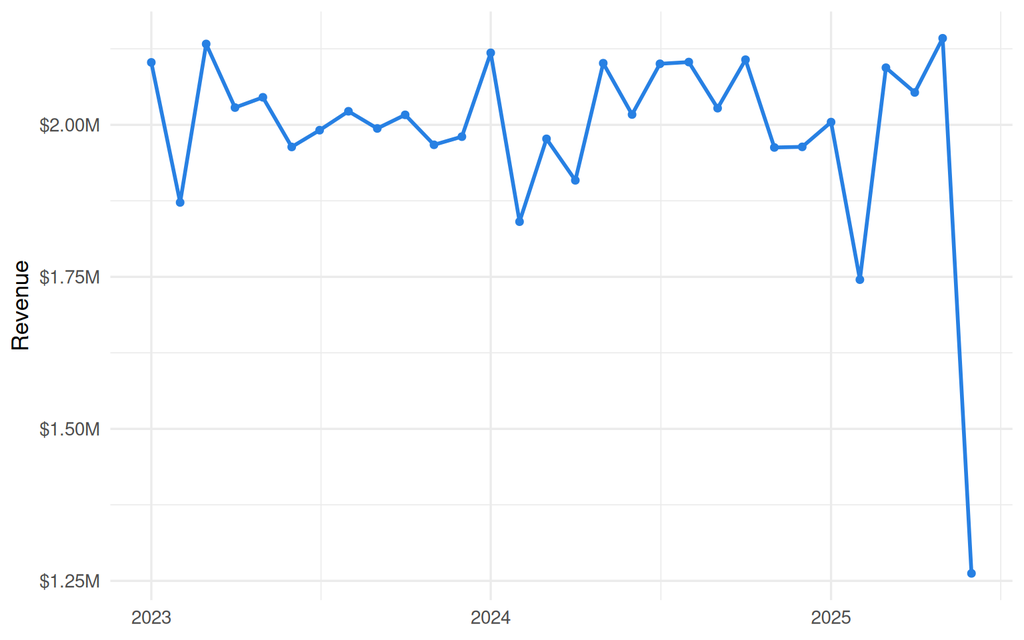

What is this dashboard about?

This dashboard uses **60,000 Shopify orders** placed between **January 2023 and June 2025** across 7 product categories, 7 countries, and 5 traffic sources.

**The question:** almost 9 out of 10 orders used a discount. *Do those discounts actually get customers to buy more?*

**The short answer:** no. Customers buy about **3 items per order whether the discount is 0% or 40%**, so deeper discounts simply shrink the order value. See the **Discounts** tab for the details.

Items per order barely moves with the discount

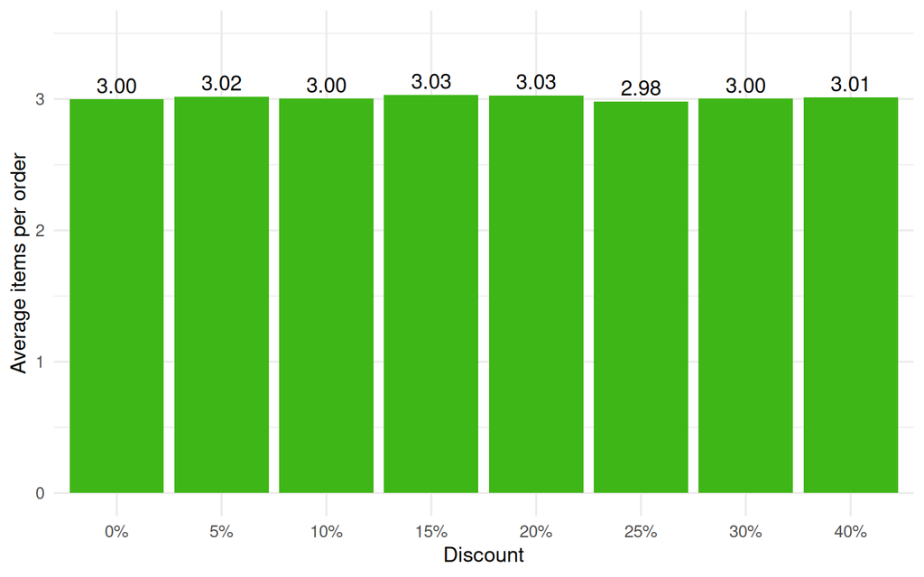

But the average order value falls with every discount step

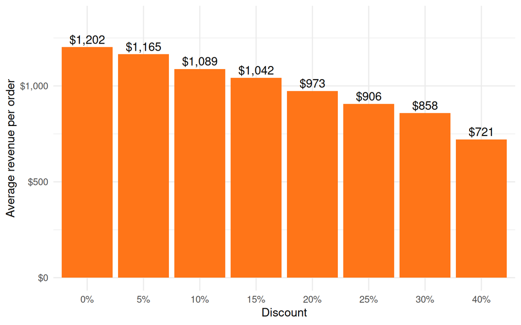

Return rate by discount level

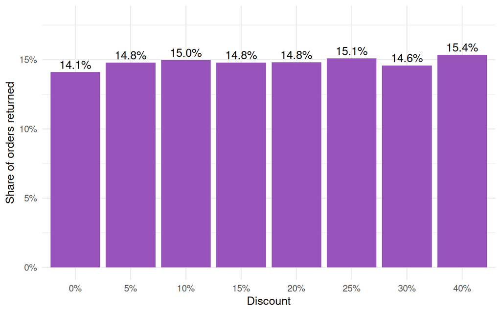

How to read this page

- **Top left:** a 40% discount does **not** lead to bigger baskets. Customers buy about **3 items** at every discount level.
- **Top right:** because quantity stays flat, each discount step lowers the order value. Orders fall from **$1,202** at full price to **$721** at 40% off, a drop of **40%**.
- **Bottom left:** deeper discounts also come with slightly *more* returns.

**Takeaway:** in this store, discounts reduce revenue without increasing how much people buy. Testing smaller or more targeted discounts could protect margin.

Revenue by traffic source

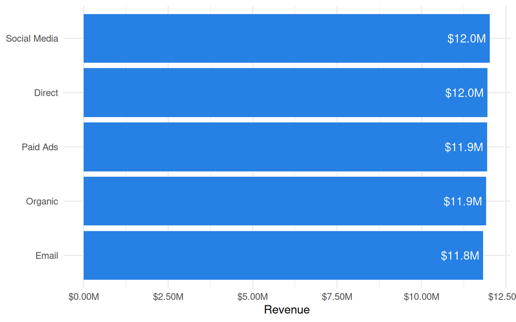

Revenue and return rate by product category

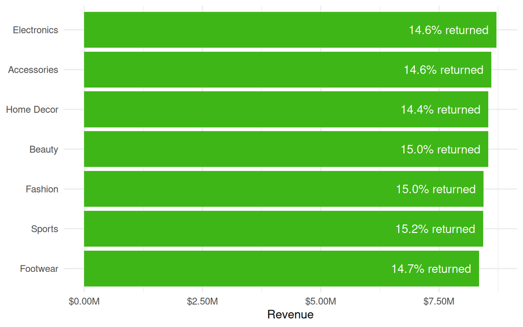

What this page shows

Revenue is spread **almost evenly** across all five traffic sources (about 20% each) and all seven product categories, and the return rate stays near **15%** everywhere. No single channel or category is carrying the business. That makes the **discount policy** the clearest lever for improving revenue.